# M45 - Espondilite Ancilosante

Pietro Garmatter

2024-08-08

```r
library(fpp3)
library(tidyverse)
library(RPostgres)
library(DBI)
# library(data.table)
library(GGally)
library(ggdist)
library(ggfortify)
library(MASS)
library(splines)
library(patchwork)
library(distributional)
# library(ggridges)
source("E:/GEATS/Estimador-AIO-SUS/lib/modelagem.R")

setwd("E:/GEATS/Estimador-AIO-SUS/M45")
load("M45.RData")

select <- dplyr::select

CID = 'M45'
```

# Exploratória

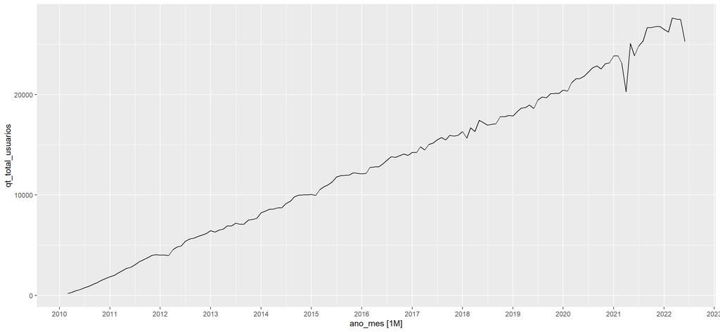

```r
autoplot(soma, qt_total_usuarios) +
  scale_x_yearmonth(date_breaks = '1 year', date_labels='%Y')
```

```r
mean(soma$qt_total_usuarios)
```

```
## [1] 13059.88
```

```r
var(soma$qt_total_usuarios)
```

```
## [1] 58980469
```

Apesar de bastantes observações, média e variância diferentes. É possível fazer análises, mas não utilizar Poisson no GLM (superdispersão).

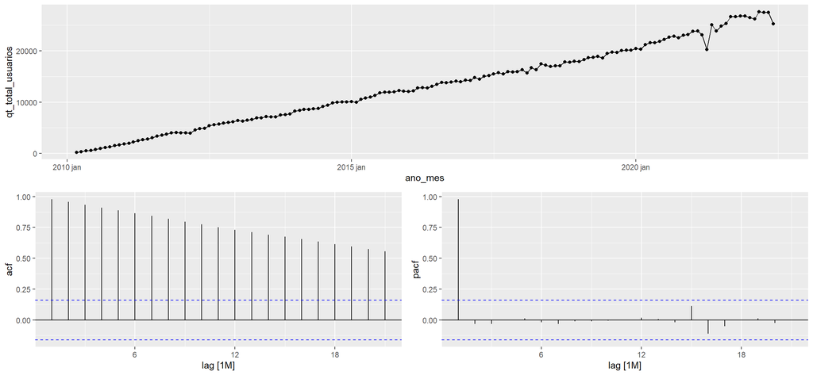

```r
gg_tsdisplay(soma, y = qt_total_usuarios, plot_type = "partial")
```

FAC e FACP sugerem processo AR(1). Série diferenciada bastante estacionária, com um pico de variância perto do final.

```r
lb12 = format(ljung_box(soma$qt_total_usuarios, lag = 12)["lb_pvalue"], nsmall = 4)
lb24 = format(ljung_box(soma$qt_total_usuarios, lag = 24)["lb_pvalue"], nsmall = 4)
```

Os testes de Ljung-Box para 12 e 24 meses rejeita a hipótese nula de que a série seja ruído branco com valores de p iguais a 0.0000 e 0.0000.

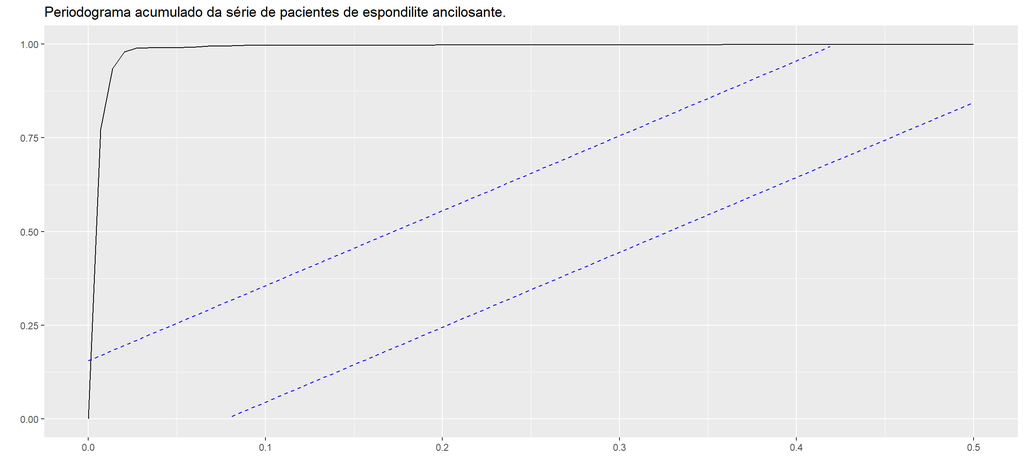

```r
ggcpgram(soma$qt_total_usuarios) +
  labs(title = 'Periodograma acumulado da série de pacientes de espondilite ancilosante.')
```

Tudo indica poder ser modelado.

# Modelagem (soma)

Propondo arima(110) com drift e sem sazonalidade.

```r
soma.treino <- soma %>% filter(ano_mes < yearmonth("2020/06"))

models <- soma.treino %>%
  model(A = ARIMA(qt_total_usuarios ~ 1 + pdq(1,1,0) + PDQ(0,0,0)),
        B = ARIMA(qt_total_usuarios),
        C = ETS(qt_total_usuarios ~ error("A") + trend("A") + season("N")),
        D = ETS(qt_total_usuarios ~ error("M") + trend("A") + season("N")),
        E = TSLM(qt_total_usuarios ~ ano_mes))

quasipoisson = glm(qt_total_usuarios ~ ano_mes, soma.treino, family = quasipoisson())

binomialneg = glm.nb(qt_total_usuarios ~ ano_mes, soma.treino)
nb.label = "F"

glance(models) %>%
  select(.model, AIC) %>%
  bind_rows(data.frame(.model = c('quasipoisson', nb.label), AIC = c(NA, AIC(binomialneg))))
```

```
## # A tibble: 7 × 2
##   .model         AIC
##   <chr>        <dbl>
## 1 A            1683.
## 2 B            1676.
## 3 C            1941.
## 4 D            1937.
## 5 E            1370.
## 6 quasipoisson   NA
## 7 F            2327.
```

O modelo E (TSLM) foi o com o melhor AIC, seguido dos A e B (ambos ARIMAs). O modelo B (ARIMA(1,1,1)(0,0,1)[12] w/ drift) teve um AIC um pouco abaixo do A.

# Análise de resíduos (soma)

```r
newdata = soma %>% filter(ano_mes >= yearmonth("2020/06"))

cast <- models %>%
  forecast(new_data = newdata)

nb.cast = predict.glm(binomialneg, newdata, type="response")
nb.mean = nb.cast #uma por mes
nb.var = var(soma$qt_total_usuarios) #var da serie ou da série predita? NESSE CASO USEI DA SERIE POIS ESTAVA DANDO P>1

size = nb.mean^2 /(nb.var - nb.mean)
prob = nb.mean / nb.var

nb.cast = fable(.model = nb.label,
                ano_mes = unique(cast$ano_mes),
                qt_total_usuarios = dist_negative_binomial(size, prob),
                mean = nb.cast,
                d1 = c(NA, diff(nb.cast)),
                response = 'qt_total_usuarios',
                distribution = 'qt_total_usuarios')
```

```
## Using `ano_mes` as index variable.
```

```r
cast <- cast %>%
  bind_rows(nb.cast)

cast %>%
  accuracy(soma,
           list(REQM = RMSE,
                winkler = winkler_score), level = 95)
```

```
## # A tibble: 6 × 4
##   .model .type   REQM winkler
##   <chr>  <chr>  <dbl>   <dbl>
## 1 A      Test   1360.  11582.
## 2 B      Test   1598.  33522.
## 3 C      Test   1436.  20693.
## 4 D      Test   1224.   9239.
## 5 E      Test   1780.  43921.
## 6 F      Test  17955. 195380.
```

O modelo D (alisamento exponencial com erros multiplicativos) teve melhor REQM e escore, seguido do modelo A proposto (ARIMA 110).

# análise dos gráficos (soma)

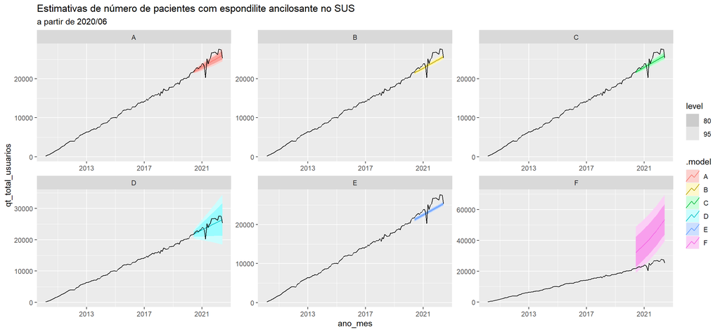

```r
cast %>%
  autoplot(soma) +
  facet_wrap(~ .model, scales = "free") +
  scale_x_yearmonth(date_breaks = '4 years', date_labels='%Y') +
  labs(title = "Estimativas de número de pacientes com espondilite ancilosante no SUS",
       subtitle = "a partir de 2020/06")
```

```r
# geom_vline(xintercept = as.Date('2021/06/01'), color = "red")
```

Percebe-se que o modelo D realmente é a melhor opção para modelar a demanda total, uma vez que contém os dados observados, mas principalmente por aproximar a média melhor aos dados. O intervalo poderia ser menor se não houvesse picos de variância imprevisíveis no período de validação.

# Análises de medicamentos

```r
tratamentos %>%
  select(no_identificador, via, somente_adulto, linha_tto_periferica, doses_inducao, doses_mensais) %>%
  unique()
```

```
##    no_identificador       via somente_adulto linha_tto_periferica doses_inducao
## 1         ADAL60438 injetavel              0                    5             0
## 6         CERT60438 injetavel              1                    5             3
## 7         ETAN60438 injetavel              0                    5             0
## 10        GOLI60438 injetavel              1                    5             0
## 11        INFL60438 injetavel              0                    5             3
## 13        METO60453      oral              0                    4             0
## 14        METO60453 injetavel              0                    4             0
## 15        SECU60469 injetavel              1                    7             5
##    doses_mensais
## 1            2.0
## 6            2.0
## 7            4.0
## 10           1.0
## 11           0.5
## 13           4.0
## 14           4.0
## 15           1.0
```

Há 8 tratamentos no total até a data final da coleta dos dados.

```r
meds <- meds %>%
  mutate(key = paste(no_identificador, via, sep = '_')) %>%
  as_tsibble(key = key, index = ano_mes)
```

```r
meds.dcmp <- meds %>%
  model(MLT = STL(qt_usuarios ~ trend() + season(0))) %>%
  components() %>%
  group_by(key) %>%
  mutate(d1 = difference(trend)) %>%
  as_tsibble(key = key) %>%
  right_join(meds) %>%
  select(-.model)
```

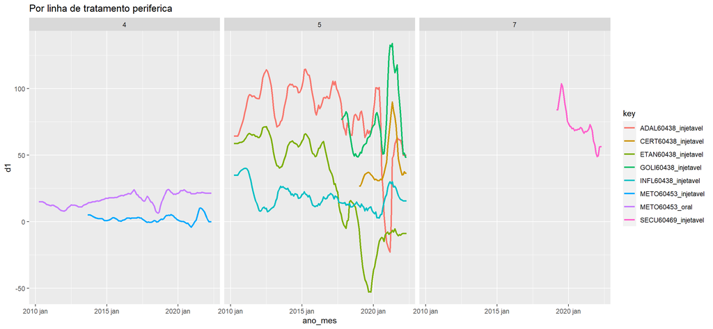

```r
ggplot(meds.dcmp, aes(x = ano_mes, y = d1, colour = key)) +
  geom_line(linewidth = 1) +
  facet_wrap(~ as.ordered(linha_tto_periferica)) +
  labs(title = "Por linha de tratamento periferica")
```

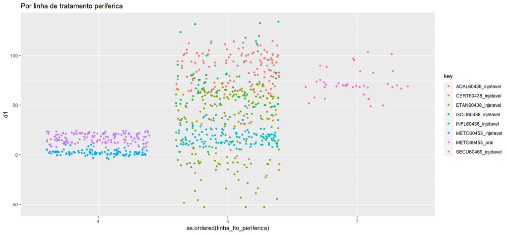

```r
ggplot(meds.dcmp, aes(x = as.ordered(linha_tto_periferica), y = d1, colour = key)) +
  geom_jitter() +
  labs(title = "Por linha de tratamento periferica")
```

Não parece ter uma relação direta, mas drogas na primeira linha (entre as estudadas) tendem a ter uma alteração constante e baixa. Segunda linha apresenta mais variancia, com drogas mostrando valores negativos. Observa-se maior variancia na linha 5 que nas outras.

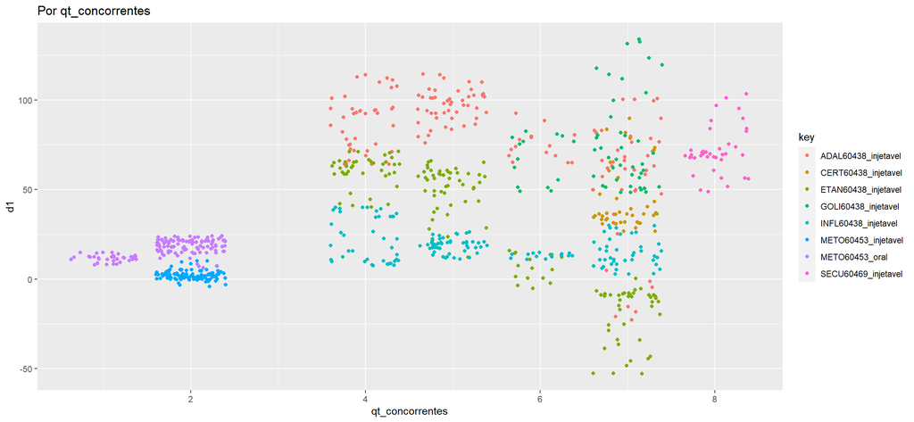

```r
ggplot(meds.dcmp, aes(x = qt_concorrentes, y = d1, colour = key)) +
  geom_jitter() +
  labs(title = "Por qt_concorrentes")
```

Percebe-se, maior variância no aumento conforme a concorrencia cresce. Contudo, O aumento parece diminuir quanto maior o numero de concorrentes (para a mesma) ou se manter estável. Comportamento varia entre as drogas.

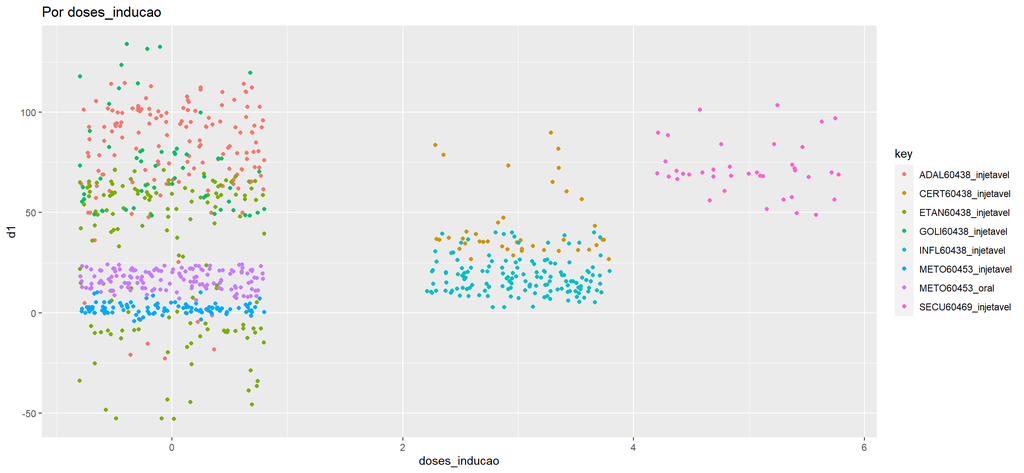

```r
ggplot(meds.dcmp, aes(x = doses_inducao, y = d1, colour = key)) +
  geom_jitter() +
  labs(title = "Por doses_inducao")
```

Entre os medicamentos que têm dose de indução, quanto maior o periodo de indução, maior parece se o aumento mensal no uso.,

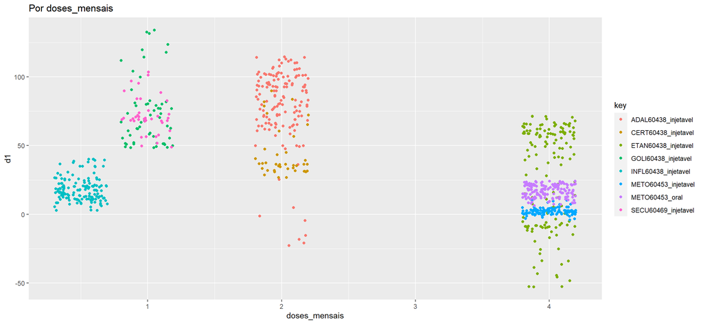

```r
ggplot(meds.dcmp, aes(x = doses_mensais, y = d1, colour = key)) +
  geom_jitter() +
  labs(title = "Por doses_mensais")
```

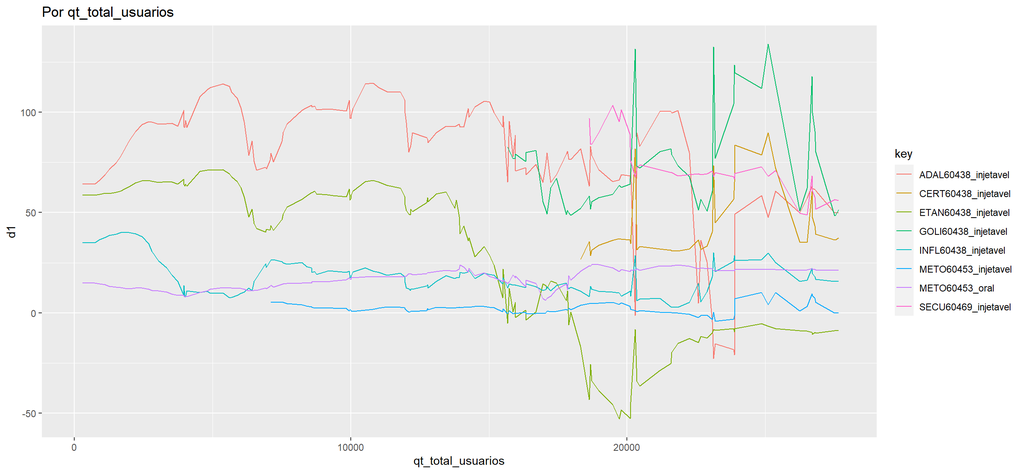

```r
ggplot(meds.dcmp, aes(x = qt_total_usuarios, y = d1, colour = key)) +
  geom_line() +
  labs(title = "Por qt_total_usuarios")
```

Fora o etanercepte, o número total de pacientes não parece influenciar na taxa de crescimento.

```r
meds.treino <- meds %>% filter(ano_mes < yearmonth("2020/06"))

colunas_tslm <- . ~ qt_concorrentes * (ano_mes + qt_total_usuarios)

colunas_lm <- . ~ qt_concorrentes +
  (as.ordered(linha_tto_periferica) +
   somente_adulto +
   no_forma_organizacao +
   doses_inducao +
   doses_mensais) * (qt_concorrentes) +
  (ano_mes + qt_total_usuarios)

model <- mltrend(
  meds.treino,
  qt_usuarios,
  group = vars(key),
  columns = colunas_lm
)
```

```
## Start:  AIC=3557.25
## d1 ~ qt_concorrentes + as.ordered(linha_tto_periferica) + somente_adulto +
##     no_forma_organizacao + doses_inducao + doses_mensais + ano_mes +
##     qt_total_usuarios + qt_concorrentes:as.ordered(linha_tto_periferica) +
##     qt_concorrentes:somente_adulto + qt_concorrentes:no_forma_organizacao +
##     qt_concorrentes:doses_inducao + qt_concorrentes:doses_mensais
##
##
## Step:  AIC=3557.25
## d1 ~ qt_concorrentes + as.ordered(linha_tto_periferica) + somente_adulto +
##     no_forma_organizacao + doses_inducao + doses_mensais + ano_mes +
##     qt_total_usuarios + qt_concorrentes:as.ordered(linha_tto_periferica) +
##     qt_concorrentes:somente_adulto + qt_concorrentes:doses_inducao +
##     qt_concorrentes:doses_mensais
##
##
## Step:  AIC=3557.25
## d1 ~ qt_concorrentes + as.ordered(linha_tto_periferica) + somente_adulto +
##     doses_inducao + doses_mensais + ano_mes + qt_total_usuarios +
##     qt_concorrentes:as.ordered(linha_tto_periferica) + qt_concorrentes:somente_adulto +
##     qt_concorrentes:doses_inducao + qt_concorrentes:doses_mensais
##
##                                                    Df Sum of Sq    RSS    AIC
## <none>                                                          167555 3557.3
## - ano_mes                                           1    1244.7 168799 3559.9
## - qt_total_usuarios                                 1    1304.2 168859 3560.2
## - qt_concorrentes:doses_mensais                     1    2794.9 170349 3565.7
## - qt_concorrentes:somente_adulto                    1   11004.3 178559 3595.5
## - qt_concorrentes:as.ordered(linha_tto_periferica)  1   11128.4 178683 3596.0
## - qt_concorrentes:doses_inducao                     1   19654.4 187209 3625.5
```

Via não pode entrar no modelo, pois só teria um nível do fator por série. Como na análise de séries temporais cada série gera um modelo, não posso usar variáveis que sejam usadas na chave. Porém, ao mesmo tempo, ao modelar as séries separadamente, perco a generalização que poderia ter para drogas novas.

Uma alternativa poderia ser a modelagem da diferenciada da tendência ignorando o tempo, considerando somente as variáveis que descrevem cada medicamento. Dessa forma, seria possível gerar um único modelo para projetar as tendências de todas as drogas

Foram feitos ajustes seguindo a estratégia de decompor as séries, diferenciar a tendência e modelar a diferenciada com base nas covariáveis (qt_concorrentes, doses_inducao, doses_mensais, qt_usuarios_totais, no_forma_organizacao, somente_adulto, linha_tto_periferica) de diferentes formas. Em especial, foram feitas tentativas de modelar diferentes relações entre as variáveis e as diferenciadas.

[output not shown]

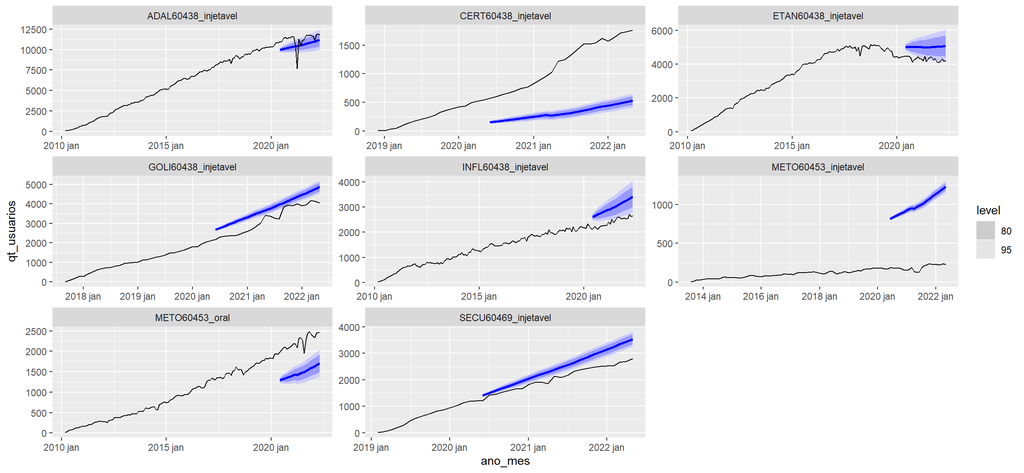

```r
predict.mltrend(model, meds.dcmp, qt_usuarios, key) %>%
  autoplot(meds, linewidth = 1) +
  facet_wrap(~key, scales = "free")
```

Apesar de parecer ter um bom ajuste às séries diferenciadas, as séries reacumuladas diferiram das observadas no período pós-treino. Decidiu-se abandonar esta abordagem e seguir com as abordagens de séries temporais clássicas, por questão de tempo.

Outras modelagens poderiam ser experimentadas com essa estratégia, buscando melhores alternativas de ajuste para os dados (GLM, por exemplo), ajustes com mais informações.

## Seguindo com a modelagem dos medicamentos

```r
for(i in unique(meds$no_identificador)) {
  print((meds %>%
     filter(no_identificador == i) %>%
     as_tibble() %>%
     select(qt_usuarios))$qt_usuarios %>%
    ggcpgram() +
    labs(title = paste("Periodograma acumulado", i)))
}
```

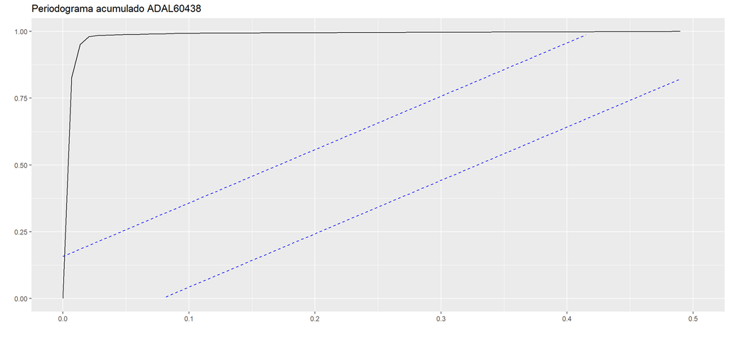

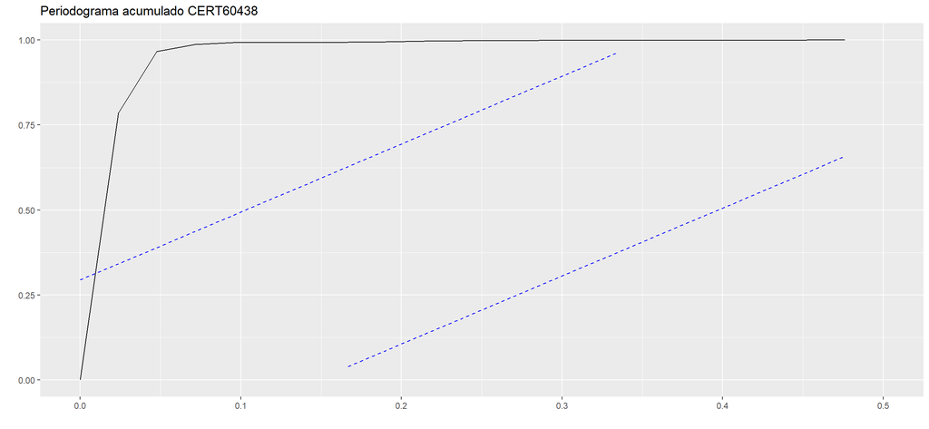

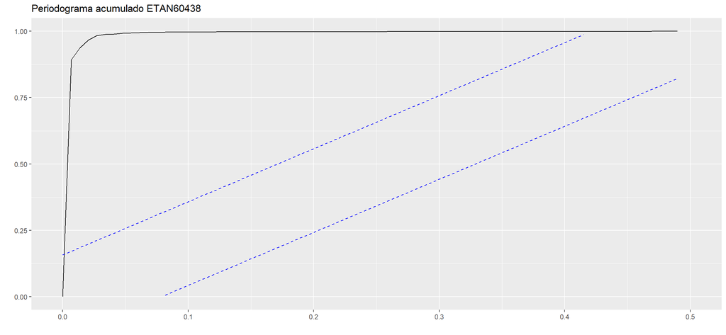

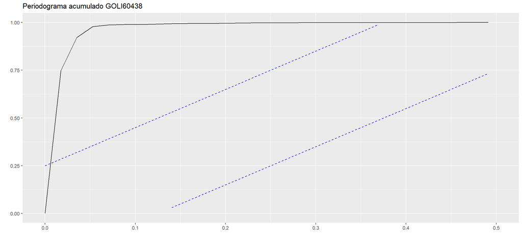

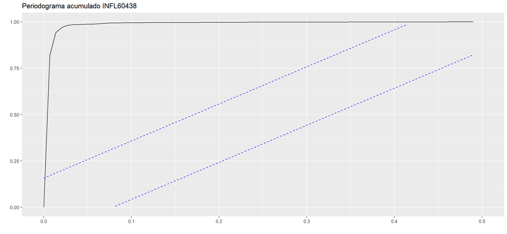

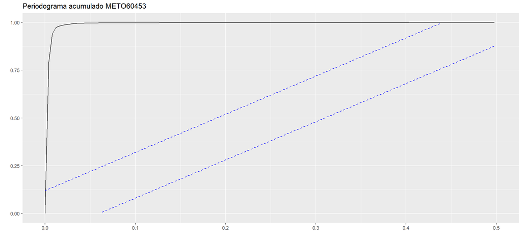

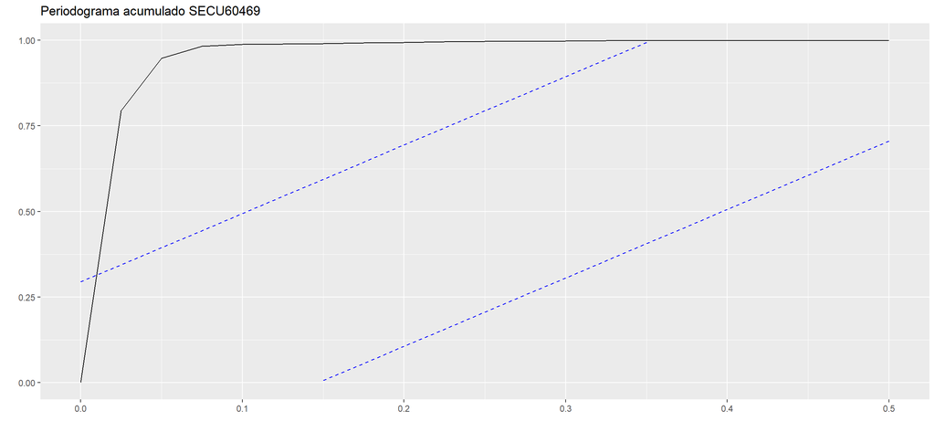

Os periodogramas acumulados de pacientes de todos os medicamentos aponta para a existência de componente sistemático a ser modelado. Sendo assim, a modelagem segue.

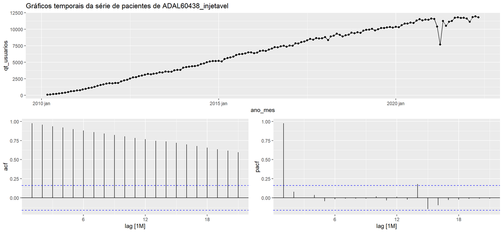

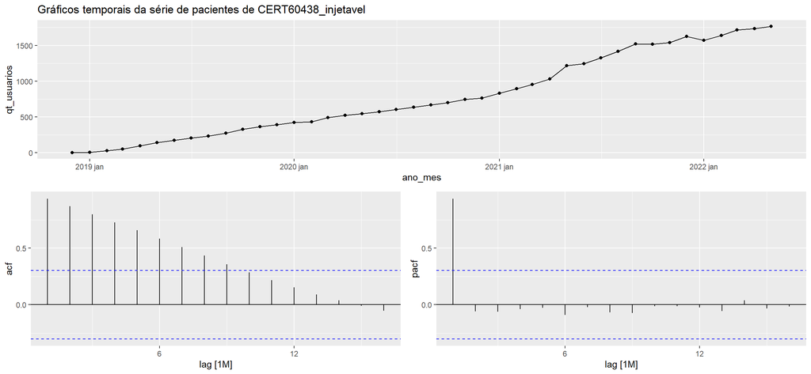

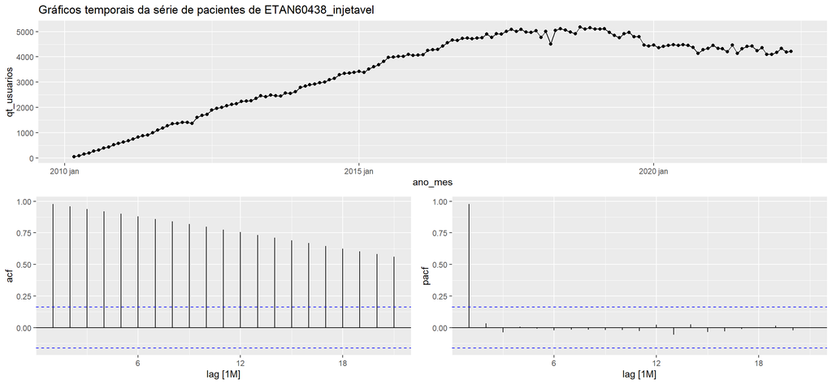

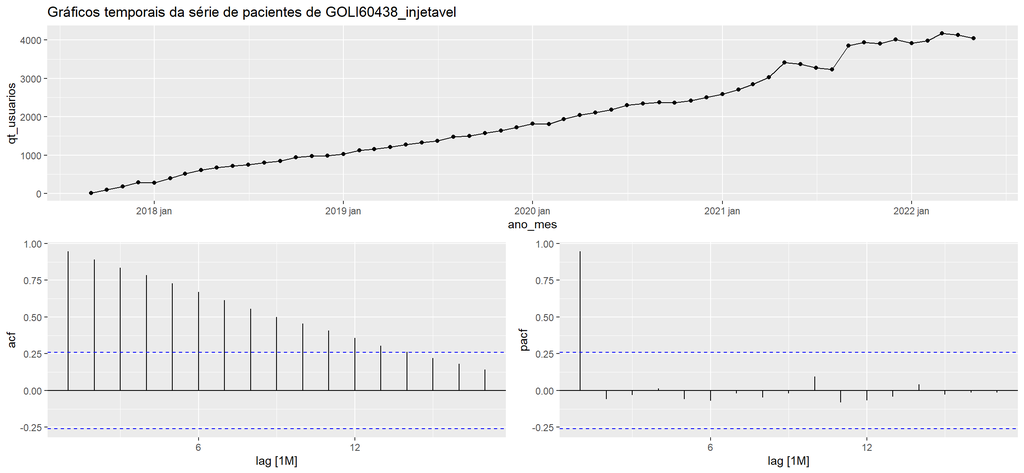

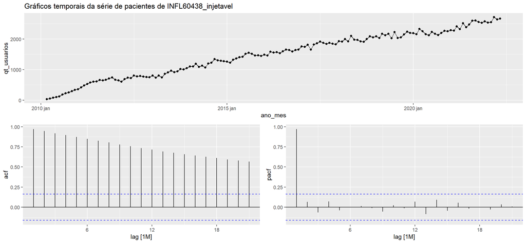

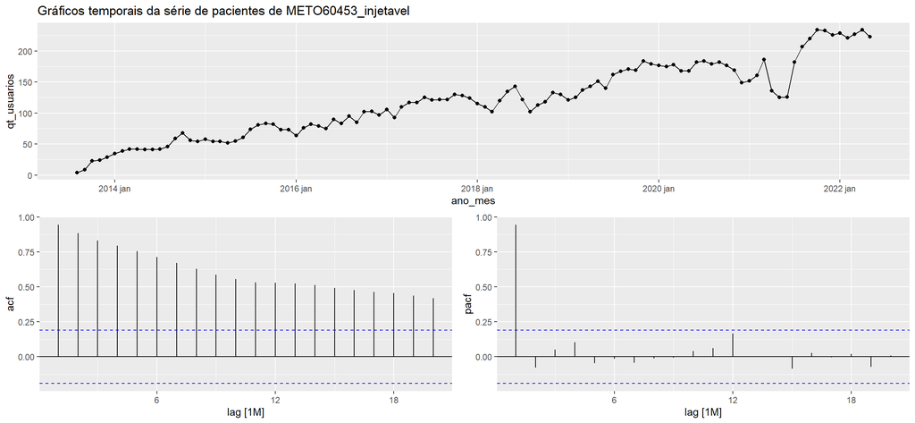

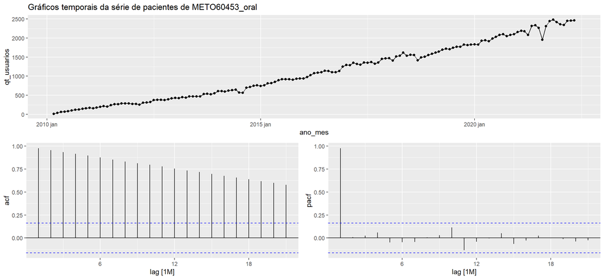

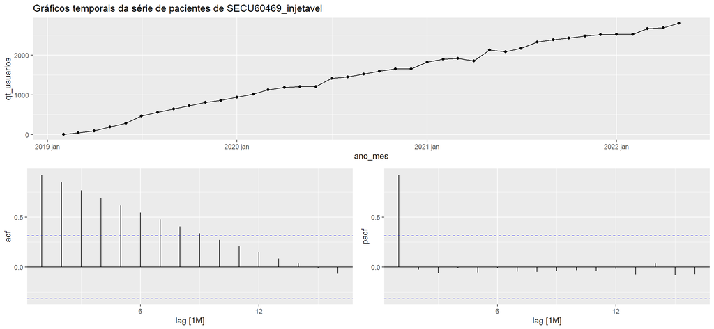

```r
for(i in unique(meds$key)) {
  print(
    meds %>%
      filter(key == i) %>%
      gg_tsdisplay(qt_usuarios, plot_type = "partial") +
      labs(title = paste("Gráficos temporais da série de pacientes de", i))
  )
}
```

A análise dos gráficos das funções de autocorrelação (ACF) e autocorrelação parcial (PACF), bem como das séries, sugere que todos os medicamentos para M45 seguem um processo AR(1): ACF decrescente infinito e PACF com pico em lag 1 e zero dali em diante. Dessa forma, foi proposto este modelo para o ARIMA A. Além do proposto, serão ajustados: ARIMA com seleção automática stepwise; LM com erros ARIMA; decomposição em trend + remainder, sendo o trend modelado com ARIMA e o remainder NAIVE; método de alisamento exponencial linear de Holt; alisamento exponencial com erros multiplicativos; LM com componentes de séries temporais.

```r
meds.treino <- meds %>% filter(ano_mes < yearmonth("2020/06"))

meds.models <- meds.treino %>%
  model(
    A = ARIMA(qt_usuarios ~ 1 + pdq(1, 1, 0) + PDQ(0, 0, 0)),
    B = ARIMA(qt_usuarios),
    C = ARIMA(qt_usuarios ~ qt_concorrentes + qt_total_usuarios + pdq()),
    D = decomposition_model(
      STL(qt_usuarios ~ trend()),
      ARIMA(trend ~ qt_concorrentes + qt_total_usuarios),
      NAIVE(remainder)
    ),
    E = ETS(qt_usuarios ~ error("A") + trend("A") + season("N")),
    F = ETS(qt_usuarios ~ error("M") + trend("A") + season("N")),
    G = TSLM(qt_usuarios)
  )
meds.models %>%
  select(key, B:D)
```

```
## # A mable: 8 x 4
## # Key:     key [8]
##   key                                                  B
##   <chr>                                          <model>
## 1 ADAL60438_injetavel <ARIMA(1,1,1)(1,0,0)[12] w/ drift>
## 2 CERT60438_injetavel            <ARIMA(0,1,0) w/ drift>
## 3 ETAN60438_injetavel                     <ARIMA(1,2,1)>
## 4 GOLI60438_injetavel            <ARIMA(0,1,0) w/ drift>
## 5 INFL60438_injetavel <ARIMA(0,1,1)(1,0,0)[12] w/ drift>
## 6 METO60453_injetavel            <ARIMA(0,1,0) w/ drift>
## 7 METO60453_oral      <ARIMA(1,1,1)(1,0,0)[12] w/ drift>
## 8 SECU60469_injetavel            <ARIMA(0,1,0) w/ drift>
## # ℹ 2 more variables: C <model>, D <model>
```

os modelos C e D não foram gerados para os medicamentos CERT60438_injetavel, METO60453_injetavel e SECU60469_injetavel. Possívelmente pelo curto período disponível de dados e, consequentemente, inexistência de mais de um valor para qt_concorrentes (VERIFICAR)

```r
# meds.models training accuracy
mm.t.acc <- meds.models %>%
  accuracy(list(REQM = RMSE), level = 95) %>%
  mutate(periodo = 0, winkler = NaN) %>%
  select(-.type) %>%
  relocate(key, .model, periodo, REQM)

# mm.t.acc <- mm.t.acc %>%
#   pivot_wider(names_from = .model,
#               names_prefix = "REQM.0.",
#               values_from = REQM)
```

```r
# meds.models forecast accuracy 12 e 24

newdata <- meds %>% filter(ano_mes > max(meds.treino$ano_mes), ano_mes <= max(meds.treino$ano_mes) + 12)

meds.cast.12 <- meds.models %>%
  forecast(new_data = newdata)

mm.f.acc.12 <- meds.cast.12 %>%
  accuracy(meds,
           list(REQM = RMSE,
                winkler = winkler_score), level = 95) %>%
  mutate(periodo = 12) %>%
  select(-.type) %>%
  relocate(key, .model, periodo, REQM, winkler) %>%
  arrange(key, .model)
  # group_by(key) %>%
  # arrange(.model, .by_group = T) %>%
  # pivot_wider(
  #   names_from = .model,
  #   names_sep = ".",
  #   values_from = c(REQM.12, winkler.12)
  # ) %>%

# 24
newdata <- meds %>% filter(ano_mes > max(meds.treino$ano_mes), ano_mes <= max(meds.treino$ano_mes) + 24)

meds.cast.24 <- meds.models %>%
  forecast(new_data = newdata)

mm.f.acc.24 <- meds.cast.24 %>%
  accuracy(meds,
           list(REQM = RMSE,
                winkler = winkler_score), level = 95) %>%
  mutate(periodo = 24) %>%
  select(-.type) %>%
  relocate(key, .model, periodo, REQM, winkler) %>%
  arrange(key, .model)

(mm.f.acc <- mm.t.acc %>%
  union(mm.f.acc.12) %>%
  union(mm.f.acc.24) %>%
  filter(!is.na(REQM)) %>%
  arrange(key, .model) %>%
  pivot_longer(cols = c(REQM, winkler), names_to = "metrica") %>%
  pivot_wider(names_from = periodo,
              values_from = value,
              names_prefix = "v."))
```

```
## # A tibble: 100 × 6
##    key                 .model metrica   v.0   v.12   v.24
##    <chr>               <chr>  <chr>   <dbl>  <dbl>  <dbl>
##  1 ADAL60438_injetavel A      REQM    124.   1281.  1168.
##  2 ADAL60438_injetavel A      winkler NaN   15266. 12996.
##  3 ADAL60438_injetavel B      REQM    119.   1255.  1113.
##  4 ADAL60438_injetavel B      winkler NaN   16866. 17439.
##  5 ADAL60438_injetavel C      REQM     58.2   839.  1234.
##  6 ADAL60438_injetavel C      winkler NaN   13218. 29875.
##  7 ADAL60438_injetavel D      REQM    100.   1108.  1731.
##  8 ADAL60438_injetavel D      winkler NaN   18559. 39139.
##  9 ADAL60438_injetavel E      REQM    123.   1272.  1153.
## 10 ADAL60438_injetavel E      winkler NaN   16157. 15778.
## # ℹ 90 more rows
```

A tabela acima apresenta as métricas dos modelos quando avaliados quanto aos seu resíduos em relação à base de treino e aos dados reais para 12 e 24 meses.